# Cause_of_Death

Jorge Alejandro, Mia Alanis, Bryce Borak

## Our Data

Our data is sourced from Kaggle from a user named “Sourav Banerjee” who is a data scientist who works at R systems. On Kaggle, he has the title of “Grandmaster”. This was the main reason we picked his two data sets because of his credibility and experience to format and clean data sets.

The two data sets that we picked for our project is “Cause of Deaths” and “World Population.” Our main focus is the “Cause of Deaths” data set. which goes into different causes of deaths around the world. These deaths range from deaths due to natural causes such as diseases and chronic health issues to death due to accidents such as drowning or fires. This data set gives a number of total deaths due to a given cause within a given year. A long with this information, it also gives us information such as what countries are affected by these causes.

Our main purpose for the “World Population” data set is for us to be able to cross refrense this data so that we can get more information of the country as well as get information for a continent.

### **Raw Input**

**World Population** * 234 Rows | 17 Columns * [Source Link](https://www.kaggle.com/datasets/iamsouravbanerjee/world-population-dataset)

**Causes of Death** * 6,120 Rows | 34 Columns * [Source Link](https://www.kaggle.com/datasets/iamsouravbanerjee/cause-of-deaths-around-the-world)

### **Final Data Set**

- **796** Rows
- **45** Columns

**Key Operations:** 1. **Filter:** Decadal years (1970-2022) 2. **Pivot:** Population into long format 3. **Join:** Inner join by Country/Year 4. **Mutate:** Added Crude Death Rate

| Country.Territory | Code | Year | Meningitis | Alzheimer.s.Disease.and.Other.Dementias | Parkinson.s.Disease | Nutritional.Deficiencies | Malaria | Drowning | Interpersonal.Violence | Maternal.Disorders | HIV.AIDS | Drug.Use.Disorders | Tuberculosis | Cardiovascular.Diseases | Lower.Respiratory.Infections | Neonatal.Disorders | Alcohol.Use.Disorders | Self.harm | Exposure.to.Forces.of.Nature | Diarrheal.Diseases | Environmental.Heat.and.Cold.Exposure | Neoplasms | Conflict.and.Terrorism | Diabetes.Mellitus | Chronic.Kidney.Disease | Poisonings | Protein.Energy.Malnutrition | Road.Injuries | Chronic.Respiratory.Diseases | … |
| --- | --- | --- | --- | --- | --- | --- | --- | --- | --- | --- | --- | --- | --- | --- | --- | --- | --- | --- | --- | --- | --- | --- | --- | --- | --- | --- | --- | --- | --- | --- |
| Afghanistan | AFG | 1990 | 2,159 | 1,116 | 371 | 2,087 | 93 | 1,370 | 1,538 | 2,655 | 34 | 93 | 4,661 | 44,899 | 23,741 | 15,612 | 72 | 696 | 0 | 4,235 | 175 | 11,580 | 1,490 | 2,108 | 3,709 | 338 | 2,054 | 4,154 | 5,945 | … |
| Afghanistan | AFG | 2000 | 3,105 | 1,291 | 416 | 3,060 | 263 | 2,048 | 2,871 | 4,271 | 97 | 186 | 5,864 | 53,919 | 32,395 | 22,920 | 99 | 1,137 | 0 | 11,323 | 52 | 13,977 | 5,429 | 2,515 | 4,182 | 499 | 3,013 | 6,581 | 7,471 | … |
| Afghanistan | AFG | 2010 | 2,410 | 1,476 | 465 | 1,974 | 377 | 1,837 | 4,130 | 4,940 | 176 | 281 | 4,416 | 53,934 | 23,701 | 23,821 | 118 | 1,367 | 350 | 6,889 | 57 | 16,718 | 8,273 | 3,413 | 4,693 | 484 | 1,932 | 7,379 | 6,969 | … |
| Afghanistan | AFG | 2015 | 1,821 | 1,652 | 511 | 1,505 | 284 | 1,730 | 5,039 | 4,320 | 230 | 339 | 3,893 | 56,875 | 21,016 | 23,953 | 131 | 1,467 | 446 | 5,509 | 58 | 18,876 | 23,667 | 4,143 | 5,153 | 496 | 1,469 | 7,730 | 6,835 | … |
| Albania | ALB | 1990 | 107 | 360 | 93 | 37 | 0 | 147 | 177 | 26 | 1 | 5 | 46 | 6,701 | 2,140 | 871 | 10 | 125 | 0 | 76 | 5 | 2,616 | 0 | 100 | 241 | 13 | 35 | 395 | 1,006 | … |
| Albania | ALB | 2000 | 48 | 438 | 117 | 22 | 0 | 91 | 309 | 8 | 2 | 21 | 21 | 7,641 | 875 | 711 | 14 | 151 | 0 | 15 | 6 | 3,073 | 1 | 141 | 244 | 24 | 21 | 259 | 753 | … |
| Albania | ALB | 2010 | 16 | 616 | 166 | 5 | 0 | 41 | 66 | 4 | 2 | 21 | 10 | 9,748 | 351 | 308 | 17 | 160 | 2 | 7 | 5 | 3,617 | 0 | 120 | 247 | 12 | 4 | 252 | 587 | … |
| Albania | ALB | 2015 | 14 | 776 | 219 | 5 | 0 | 41 | 63 | 3 | 2 | 26 | 11 | 11,754 | 418 | 199 | 18 | 160 | 1 | 7 | 4 | 4,313 | 0 | 155 | 299 | 12 | 4 | 258 | 737 | … |
| Algeria | DZA | 1990 | 838 | 1,337 | 439 | 453 | 9 | 1,207 | 491 | 1,634 | 44 | 171 | 939 | 53,488 | 8,125 | 17,931 | 75 | 1,405 | 0 | 2,908 | 35 | 10,571 | 4 | 1,743 | 3,559 | 485 | 422 | 13,438 | 4,410 | … |
| Algeria | DZA | 2000 | 586 | 2,219 | 597 | 308 | 0 | 963 | 621 | 1,027 | 123 | 327 | 625 | 64,792 | 5,897 | 13,420 | 89 | 1,591 | 48 | 1,247 | 33 | 12,910 | 2,534 | 2,062 | 4,136 | 449 | 279 | 13,538 | 5,124 | … |
| Algeria | DZA | 2010 | 399 | 3,401 | 877 | 126 | 0 | 614 | 530 | 809 | 329 | 406 | 499 | 74,239 | 5,274 | 12,387 | 94 | 1,458 | 0 | 621 | 33 | 17,706 | 318 | 3,504 | 5,764 | 370 | 108 | 11,270 | 5,887 | … |
| Algeria | DZA | 2015 | 387 | 4,343 | 1,096 | 118 | 0 | 571 | 499 | 695 | 328 | 465 | 477 | 86,306 | 5,634 | 11,344 | 103 | 1,483 | 12 | 568 | 33 | 20,663 | 112 | 4,468 | 7,045 | 363 | 98 | 11,131 | 6,739 | … |
| American Samoa | ASM | 1990 | 1 | 3 | 1 | 2 | 0 | 4 | 3 | 1 | 0 | 0 | 1 | 66 | 10 | 12 | 0 | 3 | 0 | 3 | 1 | 31 | 0 | 16 | 8 | 0 | 2 | 5 | 17 | … |
| American Samoa | ASM | 2000 | 1 | 4 | 2 | 2 | 0 | 4 | 4 | 1 | 0 | 0 | 1 | 88 | 11 | 10 | 1 | 4 | 0 | 2 | 1 | 43 | 0 | 28 | 14 | 0 | 2 | 6 | 20 | … |
| American Samoa | ASM | 2010 | 1 | 6 | 3 | 2 | 0 | 4 | 3 | 1 | 1 | 0 | 1 | 104 | 11 | 6 | 0 | 3 | 0 | 3 | 1 | 56 | 0 | 38 | 20 | 0 | 2 | 5 | 21 | … |
| American Samoa | ASM | 2015 | 1 | 7 | 3 | 2 | 0 | 4 | 3 | 1 | 1 | 0 | 1 | 116 | 11 | 5 | 1 | 4 | 0 | 3 | 0 | 63 | 0 | 40 | 24 | 0 | 2 | 5 | 22 | … |
| Andorra | AND | 1990 | 0 | 6 | 2 | 0 | 0 | 0 | 1 | 0 | 1 | 0 | 0 | 65 | 6 | 1 | 1 | 6 | 0 | 0 | 0 | 101 | 0 | 4 | 4 | 0 | 0 | 8 | 16 | … |
| Andorra | AND | 2000 | 0 | 14 | 4 | 0 | 0 | 0 | 0 | 0 | 3 | 0 | 0 | 100 | 10 | 1 | 1 | 7 | 0 | 0 | 0 | 148 | 0 | 6 | 7 | 0 | 0 | 8 | 24 | … |
| Andorra | AND | 2010 | 0 | 28 | 6 | 0 | 0 | 0 | 0 | 0 | 3 | 0 | 0 | 141 | 16 | 1 | 1 | 8 | 0 | 1 | 0 | 201 | 0 | 8 | 12 | 0 | 0 | 9 | 34 | … |
| Andorra | AND | 2015 | 0 | 33 | 6 | 0 | 0 | 0 | 0 | 0 | 3 | 0 | 0 | 155 | 19 | 0 | 1 | 8 | 0 | 1 | 0 | 203 | 0 | 8 | 15 | 0 | 0 | 8 | 36 | … |
| Angola | AGO | 1990 | 3,407 | 293 | 86 | 12,232 | 5,544 | 1,093 | 458 | 1,662 | 239 | 19 | 14,896 | 11,871 | 19,616 | 14,210 | 98 | 973 | 0 | 35,849 | 102 | 4,883 | 2,756 | 1,519 | 1,059 | 389 | 11,942 | 5,062 | 2,794 | … |
| Angola | AGO | 2000 | 4,124 | 426 | 115 | 9,327 | 11,038 | 1,302 | 582 | 1,993 | 4,784 | 29 | 17,915 | 15,555 | 22,107 | 18,518 | 125 | 1,217 | 59 | 34,141 | 120 | 6,513 | 3,420 | 1,992 | 1,403 | 488 | 9,131 | 7,978 | 3,360 | … |
| Angola | AGO | 2010 | 3,861 | 690 | 172 | 5,928 | 10,045 | 1,170 | 824 | 2,332 | 12,036 | 45 | 15,756 | 19,340 | 17,676 | 20,369 | 158 | 1,501 | 25 | 21,148 | 124 | 9,025 | 23 | 2,779 | 1,853 | 506 | 5,798 | 9,512 | 3,547 | … |
| Angola | AGO | 2015 | 2,910 | 905 | 216 | 3,970 | 9,549 | 915 | 905 | 2,166 | 13,544 | 61 | 13,149 | 21,887 | 14,257 | 19,755 | 182 | 1,691 | 75 | 17,058 | 118 | 10,753 | 1 | 3,371 | 2,139 | 448 | 3,858 | 9,012 | 3,613 | … |
| Antigua and Barbuda | ATG | 1990 | 2 | 12 | 3 | 4 | 0 | 4 | 2 | 0 | 7 | 0 | 1 | 170 | 22 | 10 | 3 | 1 | 0 | 3 | 0 | 75 | 0 | 34 | 14 | 1 | 3 | 6 | 7 | … |
| Antigua and Barbuda | ATG | 2000 | 1 | 14 | 3 | 3 | 0 | 4 | 3 | 0 | 13 | 1 | 1 | 163 | 25 | 11 | 4 | 2 | 0 | 2 | 0 | 86 | 0 | 40 | 18 | 0 | 3 | 7 | 7 | … |
| Antigua and Barbuda | ATG | 2010 | 1 | 15 | 4 | 2 | 0 | 4 | 5 | 0 | 8 | 0 | 0 | 171 | 27 | 6 | 5 | 2 | 0 | 1 | 0 | 110 | 0 | 47 | 27 | 0 | 2 | 5 | 9 | … |
| Antigua and Barbuda | ATG | 2015 | 1 | 16 | 5 | 3 | 0 | 4 | 4 | 0 | 9 | 0 | 0 | 187 | 29 | 5 | 6 | 3 | 0 | 2 | 0 | 124 | 0 | 51 | 34 | 0 | 3 | 6 | 10 | … |
| Argentina | ARG | 1990 | 772 | 4,983 | 1,494 | 1,323 | 9 | 1,128 | 2,024 | 448 | 559 | 22 | 1,641 | 98,783 | 8,684 | 9,407 | 949 | 2,758 | 21 | 1,073 | 29 | 56,399 | 162 | 7,096 | 7,129 | 308 | 1,277 | 4,361 | 9,894 | … |
| Argentina | ARG | 2000 | 591 | 7,516 | 2,081 | 1,779 | 6 | 920 | 2,544 | 399 | 1,753 | 42 | 1,045 | 91,977 | 17,874 | 6,168 | 999 | 4,394 | 19 | 760 | 94 | 67,318 | 0 | 9,715 | 11,362 | 278 | 1,693 | 5,439 | 14,803 | … |

[output cut: 70 more lines]

## What is Shown in our Data Set

We cleaned our data in a way where we were able to join both data sets. We first used the function “pivot_longer” on the “World Population Data Set.” The reason we did this was because the way the data set was originally formatted, the years were in the columns unlike the “Causes of Death Data set” where the years were separated by rows. This caused issues when trying to join both datasets as we wouldnt be able to join them by the year.

After changing the format of the “World Population Data set,” we were able to make each row a different year with a correlating country. We then joined the two data set using the year and the country so we could get the country year and continent with the information of the deaths. This makes it possible to be able to see the stats of total deaths in different continents instead of just the countries.

Not only do we focus on the location of the deaths that are taking place, but we also mutated our data set to include a “Total Deaths” column. The way we did this was by taking the putting a fucntion that takes the number of each column that we manually typed, and getting the sum of those numbers and plugging it back into the “Total deaths” collumn. The other mutation that we added was a “Crude Death Rate” where we took the total deaths and divided it byt the total population of the country. This then gets plugged into the “Crude Death Rate” column.

### What Makes up the Majority of Our Columns?

Our data set show various different death causes, both natural and unnatural. When sorting and organizing our code, we manually made a matrix which included all the “natural death” causes. These include diseases such as alzheimers and cardiovascular diseases. Once we made our filter, we were able to go in and do the opposite where we had a “Non-natural disease” matrix. Our main focus in this deep dive is going to do more with the natural deaths. With this, we make a brand new data set that is derived from the joined data set of the World population data set and the Causes of Deaths data set. From here, we filter out any column that is non-natural causes of deaths.

Because our dataset get mixed in because of the filter, we also went in to update the total deaths and the crude death rate so this way we get the total deaths and the crude death rates of the natural causes of death.

Dataset Column Classification

| Data Columns | Diseases Columns | Non-Disease Columns |
| --- | --- | --- |
| Country Territory | Meningitis | Drowning |
| Code | Alzheimer s Disease and Other Dementias | Interpersonal Violence |
| Year | Parkinson s Disease | Drug Use Disorders |
| Total Death | Nutritional Deficiencies | Alcohol Use Disorders |
| Crude Death Rate | Malaria | Self harm |
| Rank | HIV AIDS | Exposure to Forces of Nature |
| CCA3 | Tuberculosis | Environmental Heat and Cold Exposure |
| Capital | Cardiovascular Diseases | Conflict and Terrorism |
| Continent | Lower Respiratory Infections | Road Injuries |
| Area km | Neonatal Disorders | Poisonings |
| Density per km | Diarrheal Diseases | Fire Heat and Hot Substances |
| Growth Rate | Neoplasms | Maternal Disorders |
| World Population Percentage | Diabetes Mellitus |  |
| Population | Chronic Kidney Disease |  |
|  | Protein Energy Malnutrition |  |
|  | Chronic Respiratory Diseases |  |
|  | Cirrhosis and Other Chronic Liver Diseases |  |
|  | Digestive Diseases |  |
|  | Acute Hepatitis |  |

### **The Data Collaboration**

The **“Cause of Deaths”** dataset provides the *counts*, but the **“World Population”** dataset provides the *context*.

By merging them, we move from raw totals to meaningful **rates**. This allows us to answer not just *“how many died?”*, but **“how heavily was the population actually impacted?”**

### **The Investment Perspective**

**Imagine we are a global healthcare fund.** How do we choose where to invest?

We don’t just look at who has the most deaths; we analyze: - **The Crude Death Rate:** The true burden on the people. - **The Trend:** Is the crisis improving or worsening?

### **Our Core Questions**

To try and narrow down the different ways we could have used our data for, we tried simulating a corporation that is trying to find a refion of the world to invest their money to funding a cure for a certain disease or, if its a disease that can is caused by certain life style choices, putting that funding into education. Of course to start this form of thinking, we would want to try and first find which continent we want to put our investment towards. Thankfully with our data set that we have changed and updated, we can filter our data by continent, and find the total deaths per natural causes per continent. With this, we can find the total crude death rate for each continent.

- **Regional Burden:** Which continents face the heaviest impact from biological diseases?
- **Distribution & Trends:** How do specific diseases distribute across the continent?
- **The Cardiovascular Divide:** Which nations face the highest mortality burden from heart disease?

## Regional Burden

### Which continents face the heaviest impact from biological diseases?

Based on the graph below, we see the trends from 4 different years in each continent. The main bar that stands out would be the one representing Africa. This trend shows that while at some point Africa did have one of the highest mortality rates, they were able to change that within the following years.

Fun Fact

The tremendous decline in Africa’s mortality rates between 2000 and 2015 was largely driven by aggressive interventions against malaria. During this period, malaria deaths in sub-Saharan Africa plummeted. This success was primarily due to the massive upgrade of insecticide-treated bed nets (ITNs), which prevented millions of infections while people slept, alongside the widespread implementation of indoor residual spraying and more effective artemisinin-based combination therapies.

The other big major factor in this dwindling death rate was the surge in financial capital directed toward medical advancement and healthcare infrastructure on the continent. A significant portion of this progress was fueled by large corporations and global philanthropic organizations that funded medical research and supply chains, motivated by the widespread promotion and global visibility of these humanitarian efforts.

These targeted health initiatives, supported by global funding, successfully transformed malaria and other infectious diseases from a dominant, uncontrolled killer into a manageable public health challenge.

Further Reading & Sources

- [World Health Organization (WHO): Malaria’s Role in Mortality Decline](https://www.who.int/news-room/fact-sheets/detail/malaria)
- [African Development Bank: Corporate Funding and Health Progress](https://www.afdb.org/fr/news-and-events/child-mortality-rates-in-sub-saharan-africa-fall-dramatically-13279)
- [World Bank: Rates of progress in mortality decline, 2000-2019](https://openknowledge.worldbank.org/server/api/core/bitstreams/d5755e12-de39-4874-8f0c-d28d0e2863e7/content)

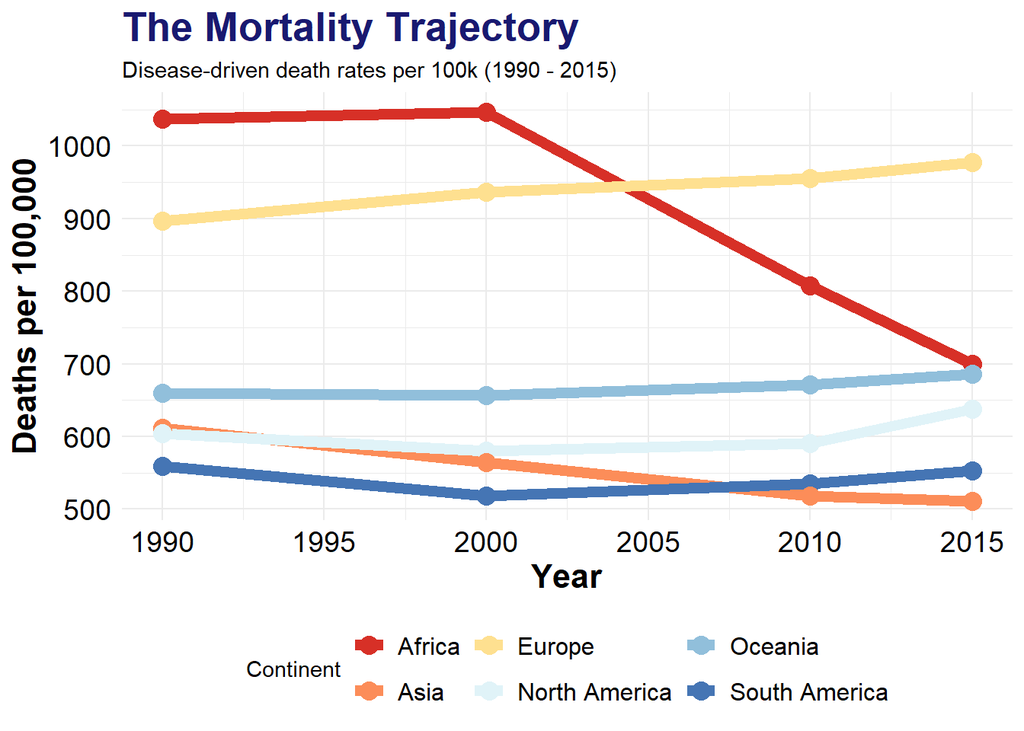

[output not shown]

We show deaths per 100,000 people so that large countries don’t overshadow smaller ones. This reveals when major outbreaks or successful medical breakthroughs shifted the numbers.

Back to the original question we were trying to answer, to be able to figure out which continent we should focus on, lets further study the other trends in this graph. When we first originally made this graph, we made a point graph that was comparing the total deaths in a continent with the total population. The result was a linear graph in which the more population a continent had, the more deaths it had.Asia of course was the continent with the most amount of deaths

That graph was scrapped due to the lack of information we were able to collect with it. With the previous graph, you would believe that Asia would have one of the higher rates of death, but the opposite is true. Asia has one of the lowest death rates compared to the rest of the continents. The second continent with the highest death rates is Europe. The trend for Europe seems to be going upward slightly. While the trend may not be drastic, it would be best to consider Europe for the funding as our ultimate goal would be to lower any high death rates and make any trend go down.

## Distribution & Trends: Europe Deep-Dive

### How do specific diseases distribute across the continent?

| Cause of Death | Countries Affected |
| --- | --- |
| Alzheimer s Disease and Other Dementias | 42 |
| Cardiovascular Diseases | 42 |
| Chronic Kidney Disease | 42 |
| Chronic Respiratory Diseases | 42 |
| Cirrhosis and Other Chronic Liver Diseases | 42 |
| Diabetes Mellitus | 42 |
| Digestive Diseases | 42 |
| HIV AIDS | 42 |
| Lower Respiratory Infections | 42 |
| Neonatal Disorders | 42 |
| Neoplasms | 42 |
| Parkinson s Disease | 42 |
| Diarrheal Diseases | 40 |
| Tuberculosis | 40 |
| Meningitis | 39 |
| Nutritional Deficiencies | 39 |
| Protein Energy Malnutrition | 39 |
| Acute Hepatitis | 36 |

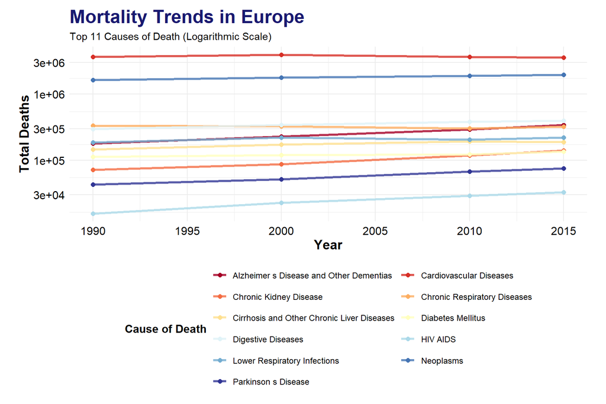

Based on the data presented, we are looking at a deep-dive into Mortality Trends in Europe between 1990 and 2015. The table on the left indicates a “Widespread” impact, showing that major causes of death like Cardiovascular Diseases and Alzheimer’s affect all 42 countries in the dataset. The line graph utilizes a logarithmic scale to track the top 11 causes of death, revealing that while cardiovascular diseases remain the leading cause of mortality, most chronic conditions are showing a steady or slightly increasing trajectory in total deaths over time. However, it is important to note that these specific numbers and trends are tied directly to the European region; if the underlying code were modified to filter for a different continent or country—such as Africa or Asia, the data would shift dramatically. For instance, infectious diseases or HIV/AIDS might show much higher totals and different growth patterns compared to the chronic, age-related conditions that currently dominate this European dataset.

## The Cardiovascular Divide: The Cardiovascular Landscape of Europe (2015)

### Which nations face the highest mortality burden from heart disease?

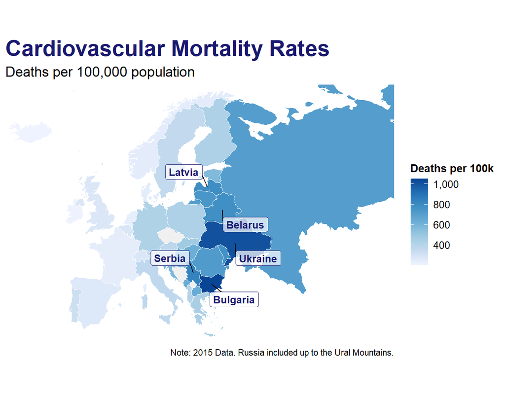

| Country | Rate |
| --- | --- |
| Bulgaria | 1050.0 |
| Ukraine | 1012.1 |
| Serbia | 833.5 |
| Latvia | 790.2 |
| Belarus | 778.8 |
| Moldova | 766.3 |
| Lithuania | 746.9 |
| Romania | 723.1 |
| Russia | 710.8 |
| North Macedonia | 639.4 |
| Montenegro | 637.1 |
| Hungary | 627.1 |
| Croatia | 579.1 |
| Estonia | 571.3 |
| Bosnia and Herzegovina | 523.6 |
| Slovakia | 478.1 |
| Monaco | 448.9 |
| Greece | 444.3 |
| Poland | 429.0 |
| Finland | 428.4 |
| Germany | 421.5 |
| Albania | 407.8 |
| Austria | 373.9 |
| Italy | 367.6 |
| Sweden | 356.8 |
| Slovenia | 338.7 |
| Portugal | 322.4 |
| Malta | 294.6 |
| Belgium | 281.4 |
| Switzerland | 274.6 |
| San Marino | 274.1 |
| United Kingdom | 271.8 |
| Spain | 264.9 |
| Denmark | 244.3 |
| Norway | 241.1 |
| France | 237.3 |
| Cyprus | 235.7 |
| Netherlands | 226.9 |
| Andorra | 216.0 |
| Luxembourg | 214.6 |
| Ireland | 206.1 |
| Iceland | 202.7 |

**Key Insight:** The data highlights a stark East-West divide. High mortality rates cluster in Eastern Europe, while Western and Northern nations show a significantly lower burden.

The Cardiovascular Divide provides heart disease mortality across Europe in 2015. The map and accompanying table illustrate a significant geographic disparity, often referred to as the “East-West divide,” where countries in Eastern Europe face a much higher mortality burden compared to their Western and Northern neighbors. For instance, Bulgaria and Ukraine show the highest rates, both exceeding 1,000 deaths per 100,000 people, while the lighter-shaded regions on the map indicate significantly lower rates in Western Europe.

It is important to recognize that these specific figures are a direct result of the current data filtering and coding. If the code were adjusted to analyze a different variable, such as total death counts rather than mortality rates, larger countries might appear to have a “heavier” burden simply due to their population size. Similarly, if the geographical filter were shifted from Europe to a different continent, the “High” and “Low” benchmarks would change entirely, as the coding would then reflect a completely different set of regional health challenges and socioeconomic factors.

Fun Fact

The high cardiovascular mortality rates observed in Europe, particularly “East-West divide”, are driven by a complex interplay of socioeconomic, behavioral, and environmental factors. Wealthier Western nations benefit from better-funded healthcare systems and policies focused on prevention, while Eastern regions often face higher psychosocial stress and limited access to timely medical interventions. Behavioral risks are a major contributor, as more than three-quarters of cardiovascular deaths in the EU are linked to modifiable factors like high salt and fat intake, tobacco use, and alcohol consumption. Additionally, biological risk factors such as hypertension affect an estimated 1 in 3 adults across the continent. Environmental triggers also play a critical role, with pollution and air quality accounting for approximately 18% of cardiovascular-related deaths in the region. As the population continues to age, these chronic conditions remain a primary health challenge for the European continent.

Further Reading & Sources

- World Health Organization (WHO): Cardiovascular Diseases Fact Sheet
- [European Commission: Safe Hearts Plan](https://health.ec.europa.eu/document/download/dfb60cde-21a5-426d-8616-e394a326abc2_en?filename=ncd_com-2025-1024_act_en.pdf)

## Summary

This analysis addresses the challenge of identifying global mortality trends and regional health disparities by shifting the focus from raw death counts to meaningful population-adjusted rates. By integrating “Cause of Death” and “World Population” datasets from Kaggle, the problem of population bias was addressed through data cleaning, joining, and the calculation of Crude Death Rates per 100,000 people. The analysis yielded significant insights, notably revealing a dramatic decline in African mortality between 2000 and 2015 due to targeted malaria interventions, as well as a stark “East-West divide” in Europe where Eastern nations face cardiovascular mortality rates exceeding 1,000 per 100,000. These findings imply that global healthcare funds should prioritize Eastern Europe for heart disease prevention and continue supporting the infrastructure that led to Africa’s successes.

However, a primary limitation is that the findings are constrained by the specific variables filtered in the code and the fact that the timeline of the primary analysis concludes in 2015. The accuracy and relevance of the data would be significantly improved if the timeline extended to the previous year, allowing for a more contemporary understanding of health trends. Furthermore, extending the data would allow for an analysis of how the COVID-19 pandemic potentially shifted mortality trajectories, disrupted healthcare infrastructure, and altered the prevalence of both communicable and chronic diseases globally. Future improvements could include expanding the deep-dive to other continents, integrating longitudinal socioeconomic data, and incorporating these recent global health events to better understand the drivers behind regional health divides.